# A Quick and Dirty Introduction to Supervised Machine Learning in R

18th of May, 2017

## What is Supervised Machine Learning?

**Machine Learning:** The construction & use of algorithms that learn from data

**Supervised:** Learning from data that have pre-assigned "labels"

## Classification of Iris Species

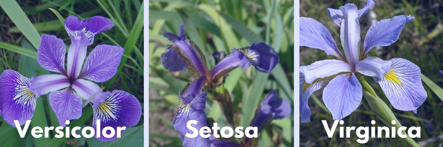

## Sepal Length & Width

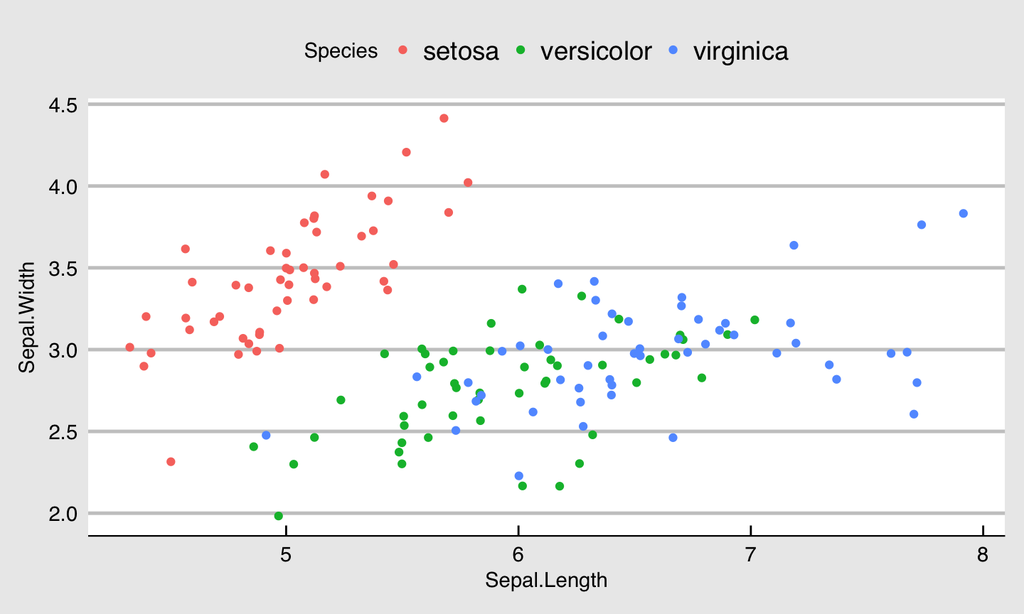

## Petal Length & Width

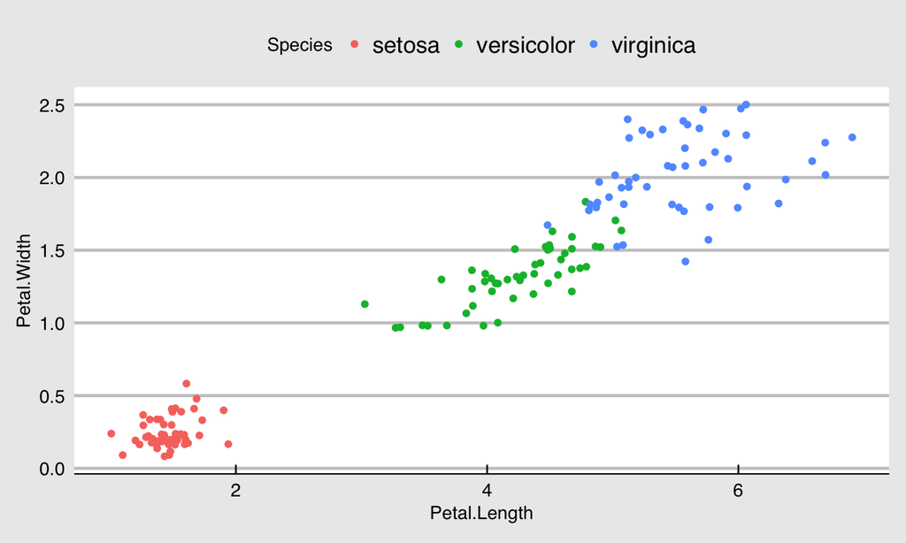

## Classification & Some Vocabulary

**The Classification Problem** - To classify a new observation based old observations. Importantly, classifications are *qualitative*.

**Machine Learning Vocabulary** * **Features** - The information used by the algorithm to make classifications (e.g. sepal width, petal height) * **Labels** - What is to be classified (e.g., species of iris: setosa, versicolor, virginica) * **Observations** - Individual instances of features and labels (if they exist) (e.g., a single iris)

## k Nearest Neighbors

Using *k* most similar observations in a training set, classify a new observation. The measure of "similarity" must be specified (e.g., Euclidean distance metric).

You'll need:

- **Training Set**: A data set with a set of *features* and *labels*
- **New Observations**: One or more observations with the *same* features, but *no labels*.

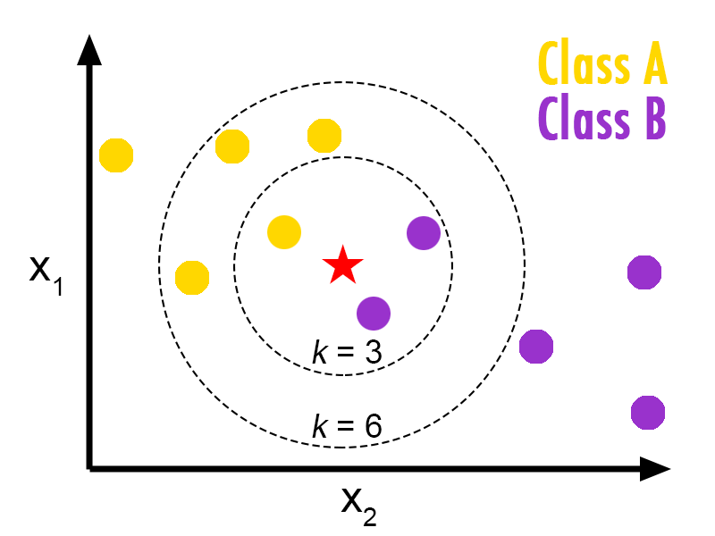

## *k*NN Algorithm

Given a training set and a *new* observation.

1. Calculate the "distance" between all training observations's features and the new observation's features
2. Select *k* training observations with the smallest "distance" to your new observation's features.
3. Aggregate the response of the *k* nearest neighbors. The aggregate is the prediction for the new observation.

## Test Data

**Question**: How can we evaluate the *k*NN algorithm's ability to classifications?

**Answer**: Test datasets, a random subset of the training data

```r
smp <- sample(nrow(iris), 0.25*nrow(iris))
trn <- iris[-smp,]
tst <- iris[smp,]
print(smp)
```

```
##  [1]  62  82  33  57   6  56  35  36  51 123  91 115  22 129 109  32 116
## [18]  54  65  53 107  73  86  34  83 108  29 121  11  93 134  67  70  81
## [35] 145  10  84
```

## *k*NN in R with the `class` package

```r
library(Hmisc, class)
features <- names(iris) %nin% c("Species")
label <- "Species"
prediction <- knn(train = trn[, features], test = tst[, features],
    cl = trn[, label], k = 3)
print(prediction)
```

```
##  [1] versicolor versicolor setosa     versicolor setosa     versicolor
##  [7] setosa     setosa     versicolor virginica  versicolor virginica
## [13] setosa     virginica  virginica  setosa     virginica  versicolor
## [19] versicolor versicolor versicolor virginica  versicolor setosa
## [25] versicolor virginica  setosa     virginica  setosa     versicolor
## [31] virginica  versicolor versicolor versicolor virginica  setosa
## [37] virginica
## Levels: setosa versicolor virginica
```

## kNN Algorithm Accuracy

*k*NN Algorithm Accuracy: <sup>Correctly Classified</sup> ⁄ <sub>Number Classified</sub>

```r
N_test = nrow(tst)
sum(prediction == tst[,label])/N_test
```

```
## [1] 0.9189189
```

## Cross-Validation

Evaluation of model performance *n* times with distinct test and training datasets, where the test set is <sup>1</sup>⁄<sub>n</sub>.

```r
set.seed(1111)
N = nrow(iris)
random <- sample(N,N) #randomized rows
smp1 <- random[1:(0.25*N)]
smp2 <- random[(0.25*N+1):(0.5*N)]
smp3 <- random[(0.5*N+1):(0.75*N)]
smp4 <- random[(0.75*N+1):N]
print(smp1)
```

```
##  [1]  70  62 135  21 108 142 127  17  78  20   1 105 104  87 119  22 123
## [18]  75 136 101 148  55 146 126   8  51   5  48 145  27  97 111  56  43
## [35] 141   4  63
```

## Exercise

1. Using 4-fold cross-validation, create 4 random test datasets
2. Iteratively test the classification accuracy for all possible *k* nearest neighbors
3. Store the results in a *k* by 4 matrix
4. Which value for *k* has the highest classification accuracy?

## kNN Performance

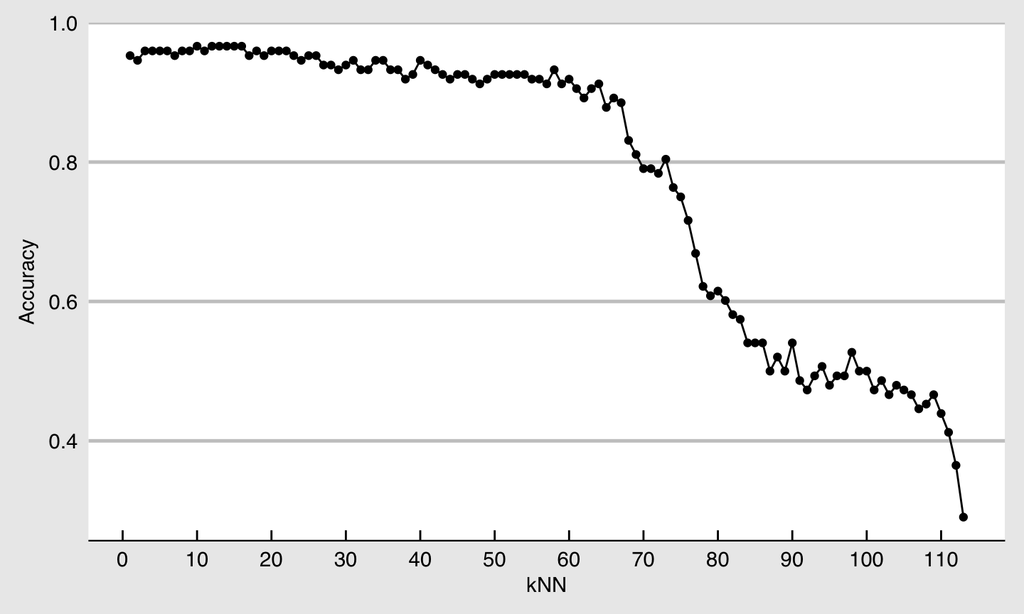

## Conclusion

If you interested in learning more, please check out DataCamp.com's Introduction to Machine Learning

[figure not shown]

[figure not shown]